# Phenology and Plant Fitness

### 4.3.3 Figures

Below are the plots for Potentilla individuals.

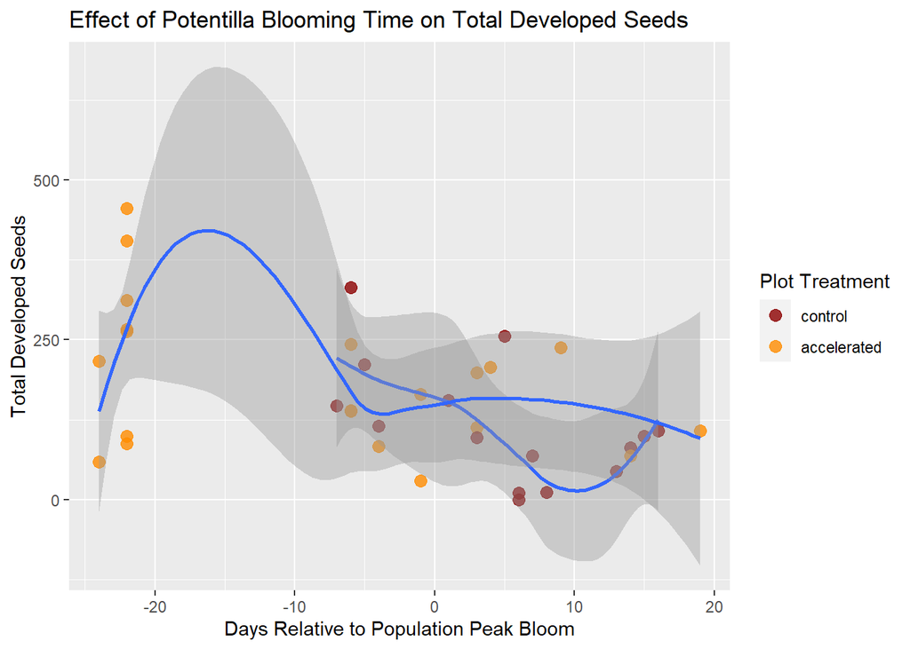

```r
ggplot(pot.open, aes(x=pot.open$relative.position, y=pot.open$total.seeds, group=plot.treat)) +
  labs(title="Effect of Potentilla Blooming Time on Total Developed Seeds", y="Total Developed Seeds",x="Days Relative to Population Peak Bloom") +
  geom_point(aes(color=plot.treat),size=3, alpha = 0.8) +
  scale_color_brewer(palette="Dark2") + labs(color="Plot Treatment") +
  scale_color_manual(labels= c("control","accelerated"), values = c("control"="darkred","manip"="darkorange")) +
  geom_smooth()
```

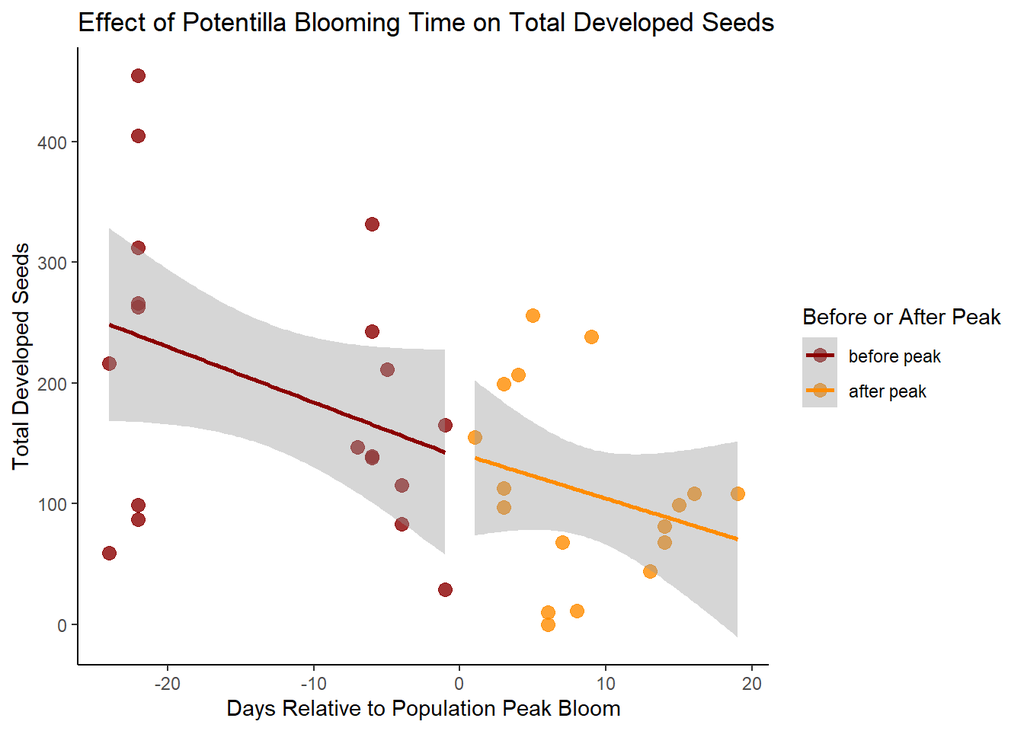

```r
ggplot(pot.open, aes(x=pot.open$relative.position, y=pot.open$total.seeds, group=pot.open$early.late)) +
  labs(y="Total Developed Seeds",x="Days Relative to Population Peak Bloom", title="Effect of Potentilla Blooming Time on Total Developed Seeds") +
  theme_classic() +
  geom_point(aes(color=early.late),size=3, alpha = 0.8) +
  scale_color_brewer(palette="Dark2") + labs(color="Before or After Peak") +
  scale_color_manual(labels= c("before peak","after peak"), values = c("early"="darkred","late"="darkorange")) +
  geom_smooth(method = "glm", aes(color=early.late))
```

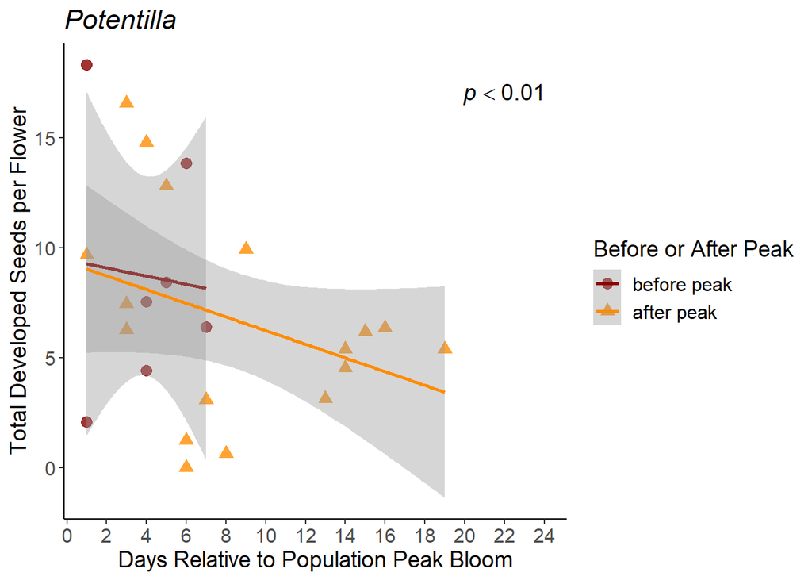

```r
ggplot(pot.open, aes(x=pot.open$deviation, y=pot.open$total.seeds/pot.open$X.flowers, group= pot.open$early.late)) +
  labs(y="Total Developed Seeds per Flower",x="Days Relative to Population Peak Bloom",title="Potentilla") +
  theme_classic() + theme(plot.title = element_text(face="italic"))+
  scale_x_continuous(breaks=seq(0,24,2)) +
  geom_point(size=3, alpha = 0.8, aes(color=early.late,shape=early.late)) +
  geom_smooth(method="glm",aes(color=early.late)) +
  scale_color_brewer(palette="Dark2") +
  labs(color="Before or After Peak",shape="Before or After Peak") +
  scale_color_manual(labels= c("before peak","after peak"), values = c("early"="darkred","late"="darkorange")) +
  scale_shape_manual(labels= c("before peak","after peak"), values = c("early"="circle","late"="triangle")) +
  annotate("text",x=22,y=17,label="italic(p) < 0.01",size=5,parse=TRUE)+
  theme(axis.text = element_text(size=12),axis.title = element_text(size=14),title = element_text(size=14),legend.text = element_text(size=12))
```

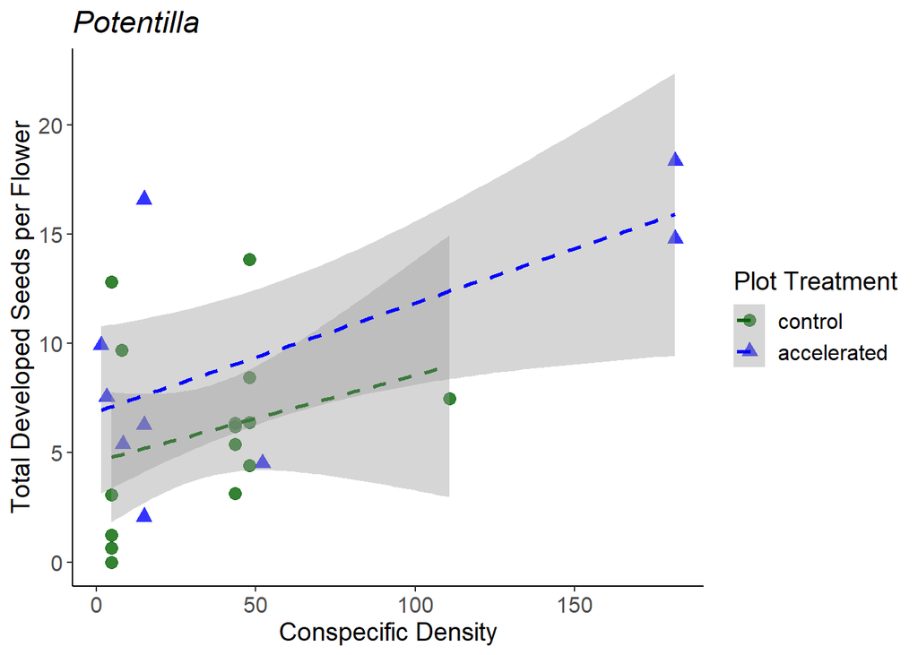

```r
ggplot(pot.open, aes(x=pot.open$number.conspecifics, y=pot.open$total.seeds/pot.open$X.flowers, group= pot.open$plot.treat)) +
  labs(y="Total Developed Seeds per Flower",x="Conspecific Density", title="Potentilla") +
  theme_classic() + theme(plot.title = element_text(face = "italic"))+
  geom_point(size=3, alpha = 0.8, aes(color=plot.treat,shape=plot.treat)) +
  geom_smooth(method="glm",linetype="dashed",aes(color=plot.treat)) +
  scale_color_brewer(palette="Dark2") +
  labs(color="Plot Treatment",shape="Plot Treatment") +
  scale_color_manual(labels= c("control","accelerated"), values = c("control"="darkgreen","manip"="blue")) +
  scale_shape_manual(labels= c("control","accelerated"), values = c("control"="circle","manip"="triangle"))+
  theme(axis.text = element_text(size=12),axis.title = element_text(size=14),title = element_text(size=14),legend.text = element_text(size=12))
```

Again we plotted the pollinator activity period.

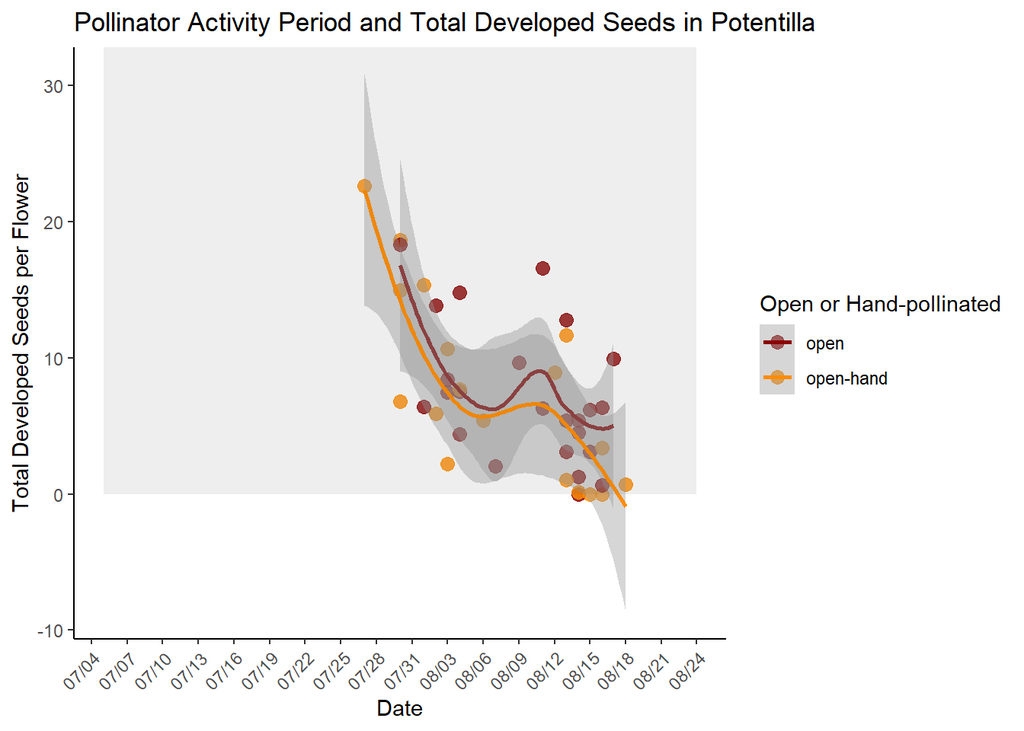

```r
ggplot(pot,aes(x=as.Date.factor(pot$midpoint), y=pot$total.seeds/pot$X.flowers, group= pot$treat)) +
  labs(y="Total Developed Seeds per Flower",x="Date", title="Pollinator Activity Period and Total Developed Seeds in Potentilla") +
  theme_classic() +
  geom_point(size=3, alpha = 0.8, aes(color=treat)) +
  geom_smooth(aes(color=treat)) +
  scale_color_brewer(palette="Dark2") +
  labs(color="Open or Hand-pollinated") +
  scale_color_manual(labels= c("open","open-hand"), values = c("open"="darkred","open-hand"="darkorange")) +
  theme(axis.text.x = element_text(angle = 45, hjust = 1)) +
  annotate("rect",xmin=as.Date.character("2019-07-05"), xmax=as.Date.character("2019-08-24"),ymin=0,ymax=Inf,alpha=0.1) +
  scale_x_date(date_breaks = "3 days", date_labels = "%m/%d")
```

# 5 Mixed Effects Models with Proportion Data

Only the Mertensia and Delphinium data included proportion of developed seeds to undeveloped ovules. When counting seeds for the Potentilla individuals, undeveloped ovules were difficult to distinguish from other elements of the carpel and were not included. Because the data are proportions and we are using the cbind function, we assume a binomial distribution.

## 5.1 Mertensia

First, we had to calculate undeveloped seeds to use the cbind function for our proportion of developed seeds.

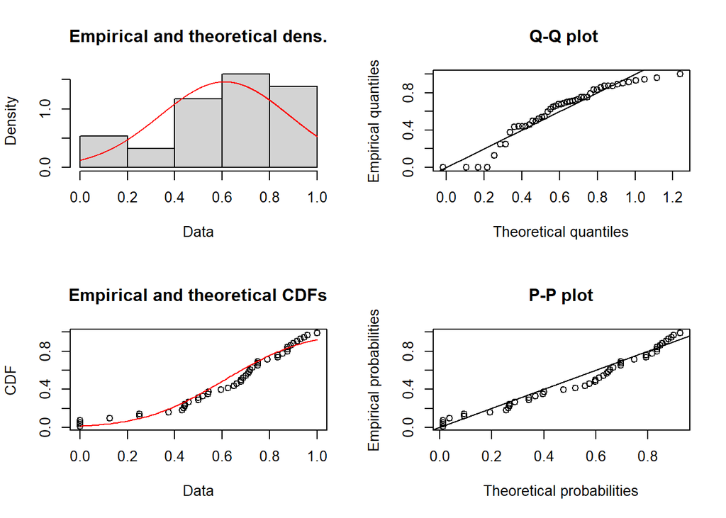

```r
plot(mert.binom) #plotting to see the fit
```

```r
mert.open$undev.seeds<-(mert.open$total.seeds-mert.open$dev.seed) #creating an undeveloped seed column for cbind

mert$undev.seeds<-(mert$total.seeds-mert$dev.seed) #creating an undeveloped seed column for cbind
```

### 5.1.1 Main Model

Below is the mixed effects model for the proportion of developed seeds. The individuals are limited to the open treatment.

```r
Mert.prop.glmmtmb<-glmmTMB(cbind(dev.seed,undev.seeds) ~ flowers:(deviation * early.late) + flowers:number.conspecifics/plot.treat + (1|site), family = binomial, data = mert.open) #Mertensia model with proportion of developed seeds using the glmmTMB package
summary(Mert.prop.glmmtmb)
```

```
##  Family: binomial  ( logit )
## Formula:
## cbind(dev.seed, undev.seeds) ~ flowers:(deviation * early.late) +
##     flowers:number.conspecifics/plot.treat + (1 | site)
## Data: mert.open
##
##      AIC      BIC   logLik deviance df.resid
##    298.9    311.9   -142.5    284.9       40
##
## Random effects:
##
## Conditional model:
##  Groups Name        Variance Std.Dev.
##  site   (Intercept) 0.1154   0.3397
## Number of obs: 47, groups:  site, 4
##
## Conditional model:
##                                               Estimate Std. Error z value
## (Intercept)                                  0.6518478  0.2323868   2.805
## flowers:deviation                            0.0022253  0.0009533   2.334
## flowers:early.latelate                       0.0260292  0.0273617   0.951
## flowers:number.conspecifics                  0.0001025  0.0001059   0.968
## flowers:deviation:early.latelate            -0.0148281  0.0083267  -1.781
## flowers:number.conspecifics:plot.treatmanip -0.0005738  0.0002024  -2.836
##                                             Pr(>|z|)
## (Intercept)                                  0.00503 **
## flowers:deviation                            0.01958 *
## flowers:early.latelate                       0.34145
## flowers:number.conspecifics                  0.33313
## flowers:deviation:early.latelate             0.07495 .
## flowers:number.conspecifics:plot.treatmanip  0.00457 **
## ---
## Signif. codes:  0 '***' 0.001 '**' 0.01 '*' 0.05 '.' 0.1 ' ' 1
```

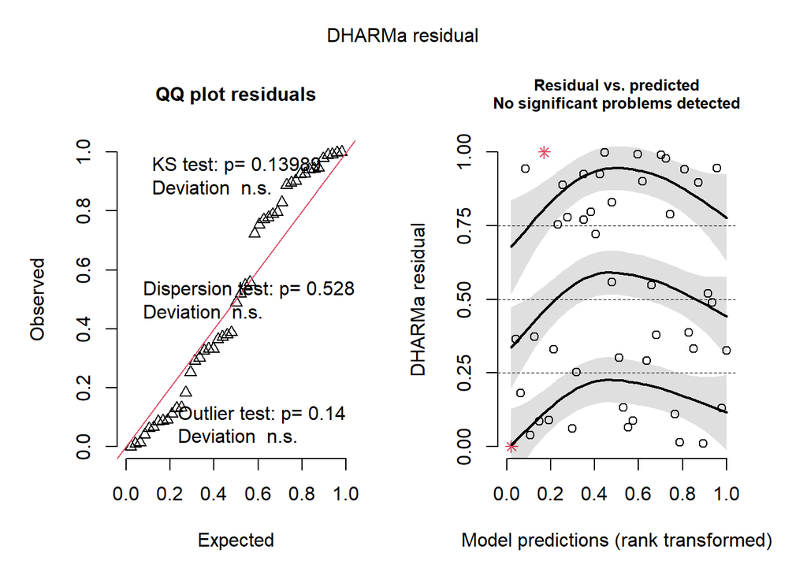

```r
mert.prop.simulation<-simulateResiduals(fittedModel = Mert.prop.glmmtmb) #creating simulation for Mertensia mixed effects model with DHARMa package
plot(mert.prop.simulation) #plotting simulation
```

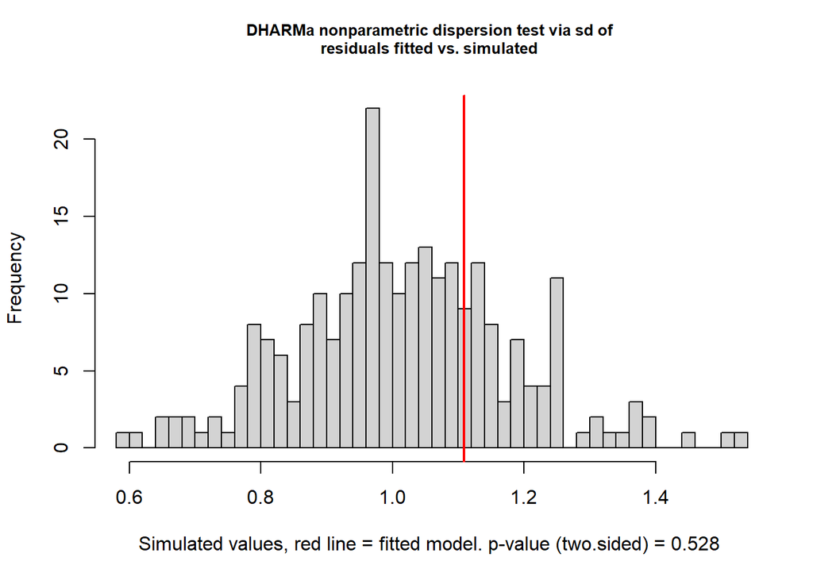

```
##
##  DHARMa nonparametric dispersion test via sd of residuals fitted vs.
##  simulated
##
## data:  simulationOutput
## dispersion = 1.0921, p-value = 0.528
## alternative hypothesis: two.sided
```

```r
testDispersion(mert.prop.simulation) #checking for overdispersion
```

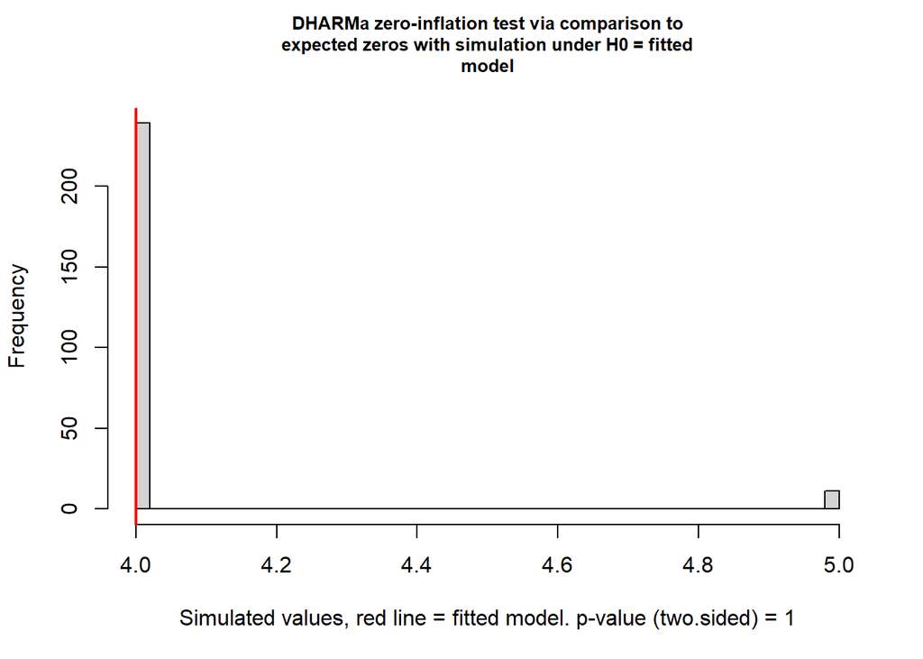

```
##
##  DHARMa zero-inflation test via comparison to expected zeros with
##  simulation under H0 = fitted model
##
## data:  simulationOutput
## ratioObsSim = 0.98912, p-value = 1
## alternative hypothesis: two.sided
```

```r
testZeroInflation(mert.prop.simulation)
```

We found a significant effect of deviation from the population peak on the proportion of developed seeds in Mertensia individuals. The Mertensia proportion data were also not overdispersed or zero-inflated. After looking at the plots below, we see that **when flower number was taken into account, Mertensia individuals that deviated from the population peak had higher seed set.**

### 5.1.2 Pollen Limitation Model

Next, we created the pollen limitation model for the Mertensia developed seeds. The model includes site and plot treatment as random effects like the models above. Now the proportion of developed seeds is the response variable.

```r
Mert.prop.treat.glmmtmb<-glmmTMB(cbind(dev.seed,undev.seeds) ~ treat/flowers + (1|site/plot.treat), family = binomial, data = mert) #model with pollen lim treatment and proportion of developed seeds using the glmmTMB package
summary(Mert.prop.treat.glmmtmb) #summary of model results
```

```
##  Family: binomial  ( logit )
## Formula:
## cbind(dev.seed, undev.seeds) ~ treat/flowers + (1 | site/plot.treat)
## Data: mert
##
##      AIC      BIC   logLik deviance df.resid
##    830.6    846.2   -409.3    818.6       94
##
## Random effects:
##
## Conditional model:
##  Groups          Name        Variance Std.Dev.
##  plot.treat:site (Intercept) 1.09e-01 3.301e-01
##  site            (Intercept) 2.04e-09 4.517e-05
## Number of obs: 100, groups:  plot.treat:site, 8; site, 4
##
## Conditional model:
##                         Estimate Std. Error z value Pr(>|z|)
## (Intercept)             0.794707   0.182801   4.347 1.38e-05 ***
## treatopen-hand         -0.467090   0.187251  -2.494  0.01262 *
## treatopen:flowers      -0.001543   0.002662  -0.580  0.56203
## treatopen-hand:flowers  0.007428   0.002628   2.826  0.00472 **
## ---
## Signif. codes:  0 '***' 0.001 '**' 0.01 '*' 0.05 '.' 0.1 ' ' 1
```

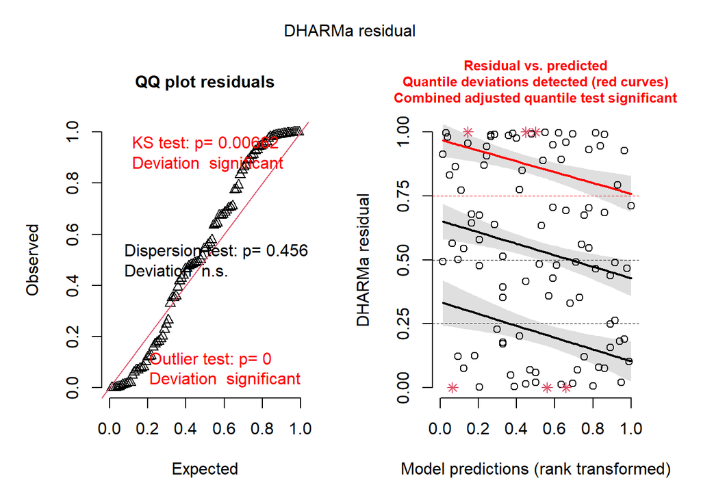

```r
mert.prop.treat.simulation<-simulateResiduals(fittedModel = Mert.prop.treat.glmmtmb) #creating simulation for Mertensia mixed effects model with DHARMa package
plot(mert.prop.treat.simulation) #plotting simulation
```

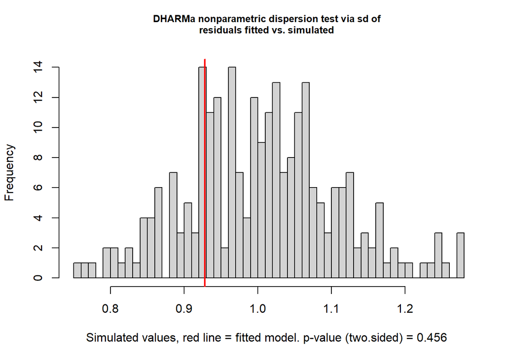

```
##
##  DHARMa nonparametric dispersion test via sd of residuals fitted vs.
##  simulated
##
## data:  simulationOutput
## dispersion = 0.92234, p-value = 0.456
## alternative hypothesis: two.sided
```

```r
testDispersion(mert.prop.treat.simulation) #checking for overdispersion
```

[figure not shown]

[output not shown]

```r
testZeroInflation(mert.prop.treat.simulation) #checking for zero inflation
```

### 5.1.3 Figures

Below are the plots for Mertensia proportion data.

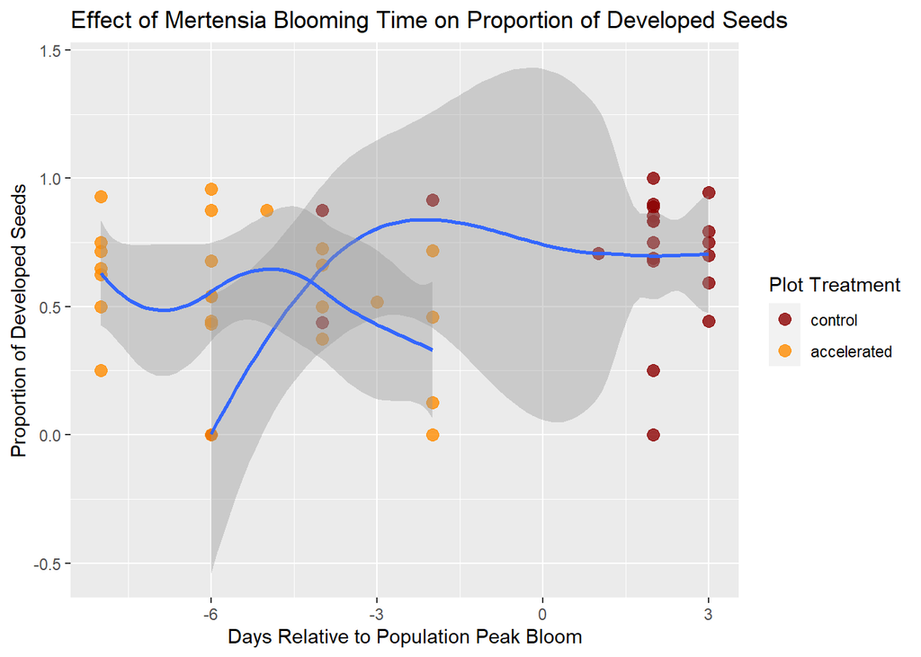

```r
mert.open<-mert.open[!is.na(mert.open$prop.dev.seeds),] #removing NA values from proportion column

ggplot(mert.open, aes(x=mert.open$relative.position, y=mert.open$prop.dev.seeds, group=plot.treat)) +
  labs(y="Proportion of Developed Seeds",x="Days Relative to Population Peak Bloom",title="Effect of Mertensia Blooming Time on Proportion of Developed Seeds") +
  geom_point(aes(color=plot.treat),size=3, alpha = 0.8) +
  scale_color_brewer(palette="Dark2") + labs(color="Plot Treatment") +
  scale_color_manual(labels= c("control","accelerated"), values = c("control"="darkred","manip"="darkorange")) +
  geom_smooth()
```

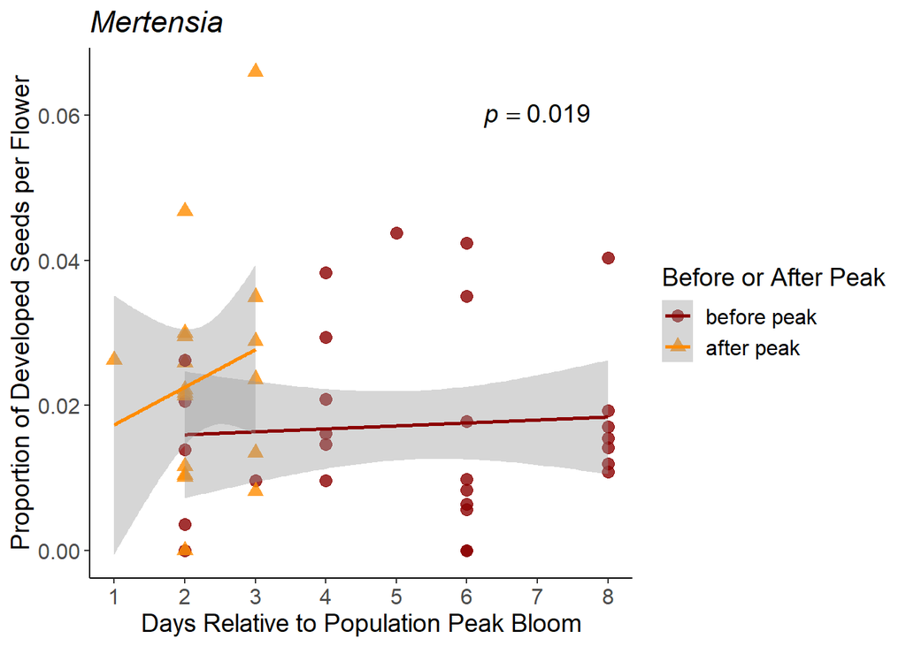

```r
ggplot(mert.open, aes(x=mert.open$deviation, y=mert.open$prop.dev.seeds/mert.open$flowers, group= mert.open$early.late)) +
  labs(y="Proportion of Developed Seeds per Flower",x="Days Relative to Population Peak Bloom",title="Mertensia") +
  theme_classic() + theme(plot.title = element_text(face = "italic"))+
  scale_x_continuous(breaks=seq(0,8,1)) +
  geom_point(size=3, alpha = 0.8, aes(color=early.late,shape=early.late)) +
  geom_smooth(method="glm",aes(color=early.late)) +
  scale_color_brewer(palette="Dark2") +
  labs(color="Before or After Peak",shape="Before or After Peak") +
  scale_color_manual(labels= c("before peak","after peak"), values = c("early"="darkred","late"="darkorange")) +
  scale_shape_manual(labels= c("before peak","after peak"), values = c("early"="circle","late"="triangle")) +
  annotate("text",x=7,y=0.06,label="italic(p) == 0.019",size=5,parse=TRUE)+
  theme(axis.text = element_text(size=12),axis.title = element_text(size=14),title = element_text(size=14),legend.text = element_text(size=12))
```

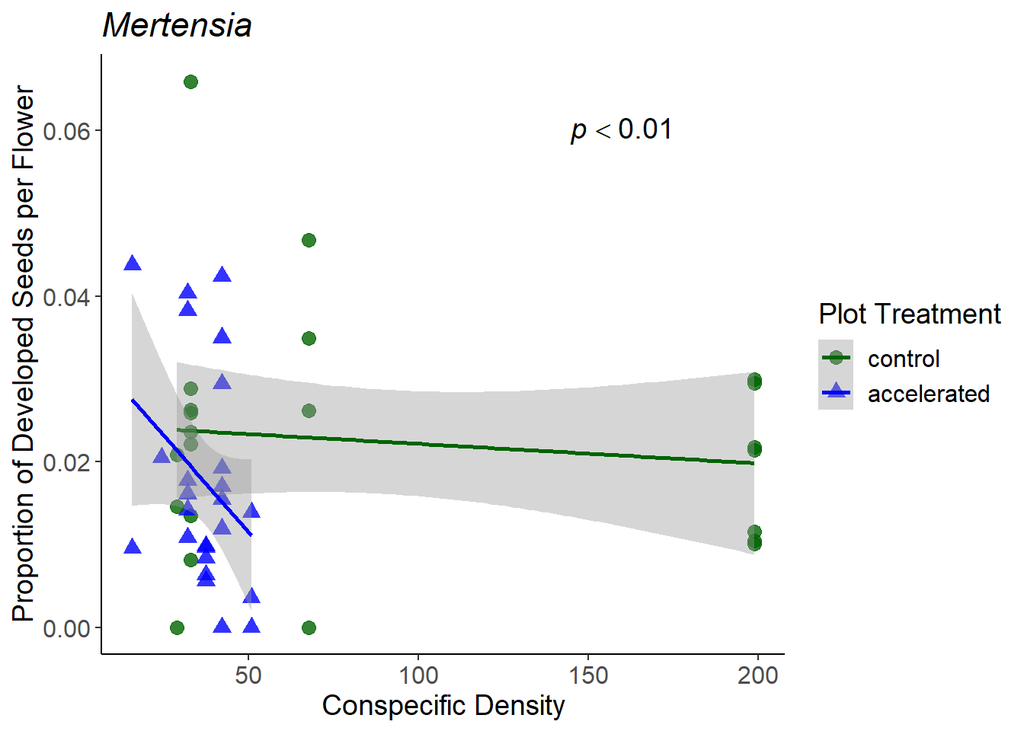

```r
ggplot(mert.open, aes(x=mert.open$number.conspecifics, y=mert.open$prop.dev.seeds/mert.open$flowers, group= mert.open$plot.treat)) +
  labs(y="Proportion of Developed Seeds per Flower",x="Conspecific Density",title="Mertensia") +
  theme_classic() +theme(plot.title = element_text(face = "italic"))+
  geom_point(size=3, alpha = 0.8, aes(color=plot.treat,shape=plot.treat)) +
  geom_smooth(method="glm",aes(color=plot.treat)) +
  scale_color_brewer(palette="Dark2") +
  labs(color="Plot Treatment",shape="Plot Treatment") +
  scale_color_manual(labels= c("control","accelerated"), values = c("control"="darkgreen","manip"="blue")) +
  scale_shape_manual(labels= c("control","accelerated"), values = c("control"="circle","manip"="triangle")) +
  annotate("text",x=160,y=0.06,label="italic(p) < 0.01",size=5,parse=TRUE) +
  theme(axis.text = element_text(size=12),axis.title = element_text(size=14),title = element_text(size=14),legend.text = element_text(size=12))
```

Finally, we added pollinator activity.

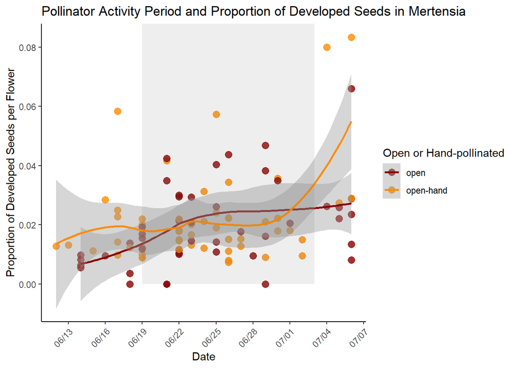

```r
ggplot(mert, aes(x=as.Date.factor(mert$midpoint), y=mert$prop.dev.seeds/mert$flowers, group= mert$treat)) +
  labs(y="Proportion of Developed Seeds per Flower",x="Date", title="Pollinator Activity Period and Proportion of Developed Seeds in Mertensia") +
  theme_classic() +
  geom_point(size=3, alpha = 0.8, aes(color=treat)) +
  geom_smooth(aes(color=treat)) +
  scale_color_brewer(palette="Dark2") +
  labs(color="Open or Hand-pollinated") +
  scale_color_manual(labels= c("open","open-hand"), values = c("open"="darkred","open-hand"="darkorange")) +
  theme(axis.text.x = element_text(angle = 45, hjust = 1)) +
  annotate("rect",xmin=as.Date.character("2019-06-19"), xmax=as.Date.character("2019-07-03"),ymin=0,ymax=Inf,alpha=0.1) +
  scale_x_date(date_breaks = "3 days", date_labels = "%m/%d")
```

## 5.2 Delphinium

We checked the fit of the Delphinium data with binomial errors.

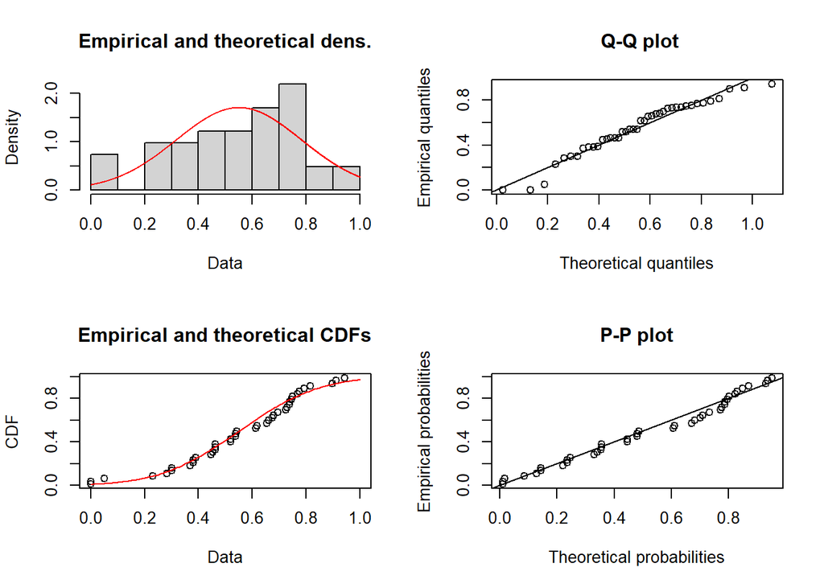

```r
plot(delph.binom) #plotting to see the fit
```

### 5.2.1 Main Model

We assessed the Delphinium data with a mixed effects model for the proportion of developed seeds. The individuals are still limited to the open treatment.

```r
Delph.prop.glmmtmb<-glmmTMB(cbind(dev.seed.total,undev.seed.total) ~ X.flowers:(deviation * early.late) + X.flowers:number.conspecifics/plot.treat + (1|site), family = betabinomial, data = delph.open) #modeling Delphinium proportion of developed seeds with glmmTMB package
summary(Delph.prop.glmmtmb)
```

```
##  Family: betabinomial  ( logit )
## Formula:
## cbind(dev.seed.total, undev.seed.total) ~ X.flowers:(deviation *
##     early.late) + X.flowers:number.conspecifics/plot.treat +      (1 | site)
## Data: delph.open
##
##      AIC      BIC   logLik deviance df.resid
##    334.5    348.2   -159.2    318.5       33
##
## Random effects:
##
## Conditional model:
##  Groups Name        Variance  Std.Dev.
##  site   (Intercept) 5.607e-09 7.488e-05
## Number of obs: 41, groups:  site, 4
##
## Dispersion parameter for betabinomial family (): 4.85
##
## Conditional model:
##                                                 Estimate Std. Error z value
## (Intercept)                                   -0.2054242  0.3484833  -0.590
## X.flowers:deviation                            0.0159357  0.0112946   1.411
## X.flowers:early.latelate                       0.1346731  0.1556862   0.865
## X.flowers:number.conspecifics                  0.0003517  0.0017993   0.196
## X.flowers:deviation:early.latelate            -0.0073549  0.0337245  -0.218
## X.flowers:number.conspecifics:plot.treatmanip -0.0014028  0.0017679  -0.793
##                                               Pr(>|z|)
## (Intercept)                                      0.556
## X.flowers:deviation                              0.158
## X.flowers:early.latelate                         0.387
## X.flowers:number.conspecifics                    0.845
## X.flowers:deviation:early.latelate               0.827
## X.flowers:number.conspecifics:plot.treatmanip    0.428
```

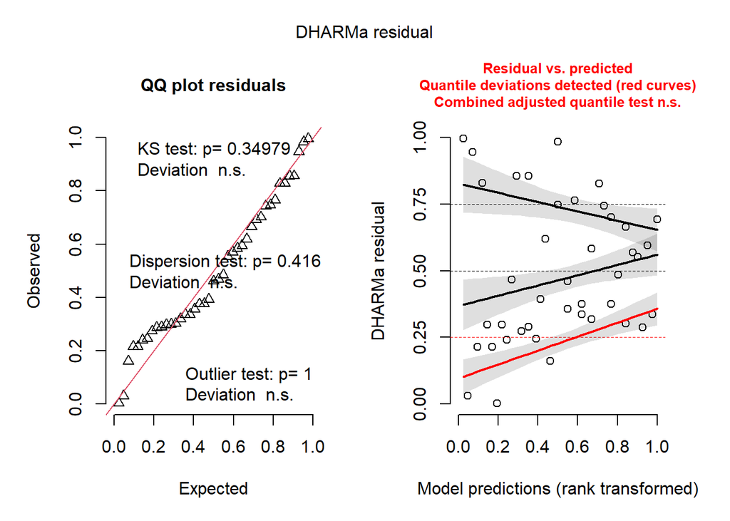

```r
delph.prop.simulation<-simulateResiduals(fittedModel = Delph.prop.glmmtmb) #creating simulation for Delphinium model
plot(delph.prop.simulation) #plotting simulation
```

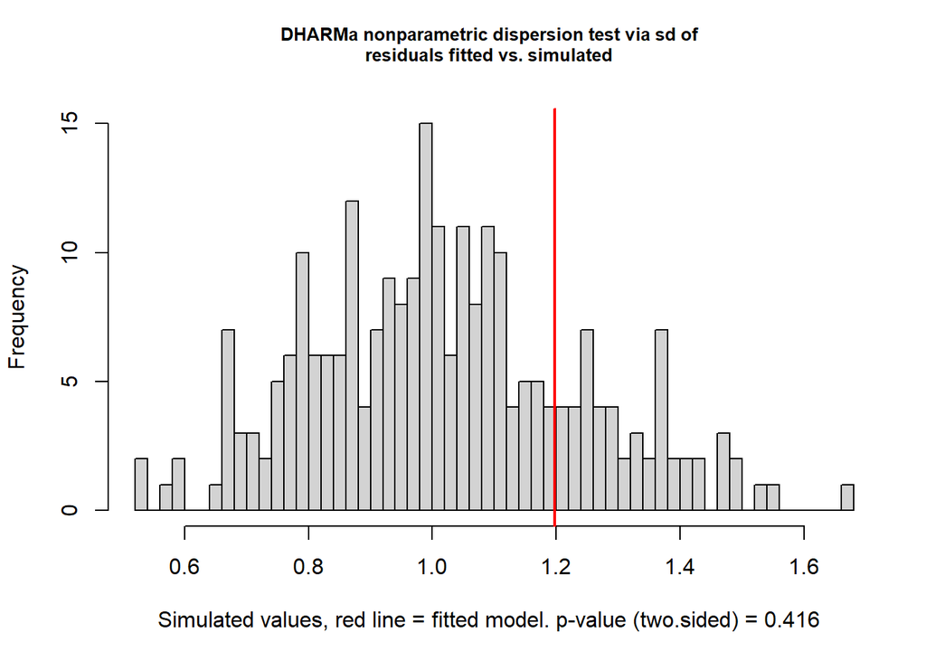

```
##
##  DHARMa nonparametric dispersion test via sd of residuals fitted vs.
##  simulated
##
## data:  simulationOutput
## dispersion = 1.1764, p-value = 0.416
## alternative hypothesis: two.sided
```

```r
testDispersion(delph.prop.simulation) #checking for overdispersion
```

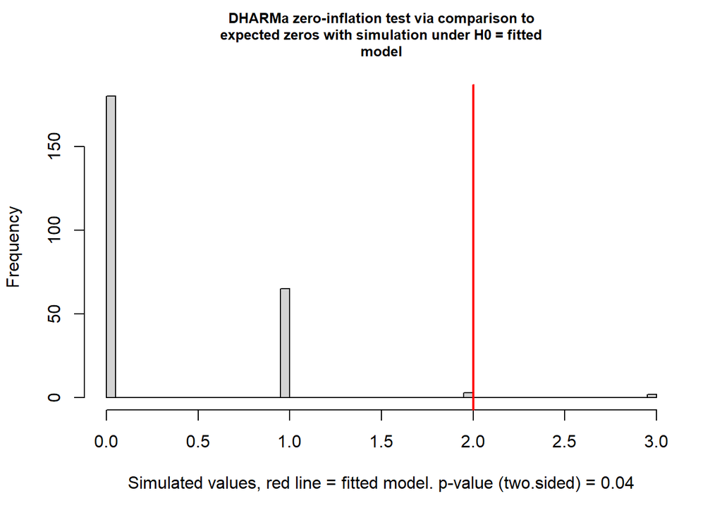

```
##
##  DHARMa zero-inflation test via comparison to expected zeros with
##  simulation under H0 = fitted model
##
## data:  simulationOutput
## ratioObsSim = 6.4935, p-value = 0.04
## alternative hypothesis: two.sided
```

```r
testZeroInflation(delph.prop.simulation) #checking for zero inflation
```

The seed set of Delphinium individuals wasn’t significantly affected by relative blooming time and conspecific density. Our model was overdispersed to binomial errors, but not to betabinomial errors. **Relative blooming time and conspecific density do not have an effect on the proportion of developed seeds in Delphinium individuals.**

### 5.2.2 Pollen Limitation Model

We created the mixed effects model for the pollen-supplemented Delphinium individuals. Like the Mertensia model above, site and plot treatment are random effects, the interaction between pollen limitation treatment and number of flowers is the fixed effect, and proportion of developed seeds is the response variable.

```r
Delph.prop.treat.glmmtmb<-glmmTMB(cbind(dev.seed.total,undev.seed.total) ~ treat/X.flowers + (1|site/plot.treat), family = betabinomial, data = delph) #modeling pollen lim and proportion of developed seeds with glmmTMB package
summary(Delph.prop.treat.glmmtmb) #model summary
```

```
##  Family: betabinomial  ( logit )
## Formula:
## cbind(dev.seed.total, undev.seed.total) ~ treat/X.flowers + (1 |
##     site/plot.treat)
## Data: delph
##
##      AIC      BIC   logLik deviance df.resid
##    660.3    677.3   -323.2    646.3       77
##
## Random effects:
##
## Conditional model:
##  Groups          Name        Variance  Std.Dev.
##  plot.treat:site (Intercept) 3.190e-09 5.648e-05
##  site            (Intercept) 2.482e-01 4.982e-01
## Number of obs: 84, groups:  plot.treat:site, 7; site, 4
##
## Dispersion parameter for betabinomial family (): 5.69
##
## Conditional model:
##                          Estimate Std. Error z value Pr(>|z|)
## (Intercept)              -0.53669    0.49501  -1.084   0.2783
## treatopen-hand            0.59997    0.57195   1.049   0.2942
## treatopen:X.flowers       0.19255    0.08753   2.200   0.0278 *
## treatopen-hand:X.flowers  0.10651    0.07554   1.410   0.1585
## ---
## Signif. codes:  0 '***' 0.001 '**' 0.01 '*' 0.05 '.' 0.1 ' ' 1
```

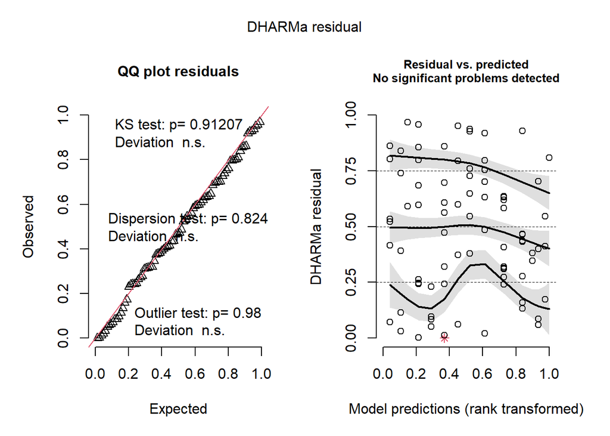

```r
delph.prop.treat.simulation<-simulateResiduals(fittedModel = Delph.prop.treat.glmmtmb) #creating simulation for Delphinium model
plot(delph.prop.treat.simulation) #plotting simulation
```

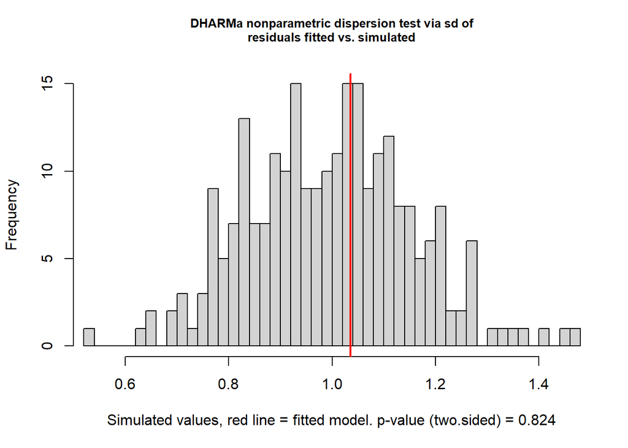

```
##
##  DHARMa nonparametric dispersion test via sd of residuals fitted vs.
##  simulated
##
## data:  simulationOutput
## dispersion = 1.0402, p-value = 0.824
## alternative hypothesis: two.sided
```

```r
testDispersion(delph.prop.treat.simulation) #checking for overdispersion
```

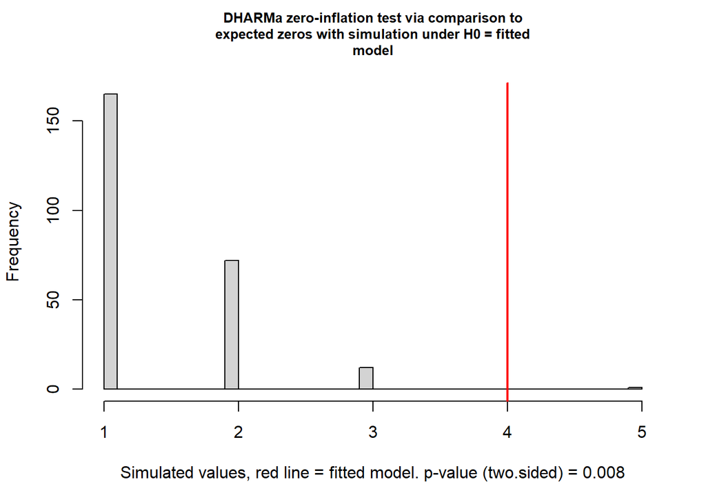

```
##
##  DHARMa zero-inflation test via comparison to expected zeros with
##  simulation under H0 = fitted model
##
## data:  simulationOutput
## ratioObsSim = 2.8571, p-value = 0.008
## alternative hypothesis: two.sided
```

```r
testZeroInflation(delph.prop.treat.simulation) #checking for zero inflation
```

### 5.2.3 Figures

Below are the plots for the proportion of developed seeds in Delphinium individuals.

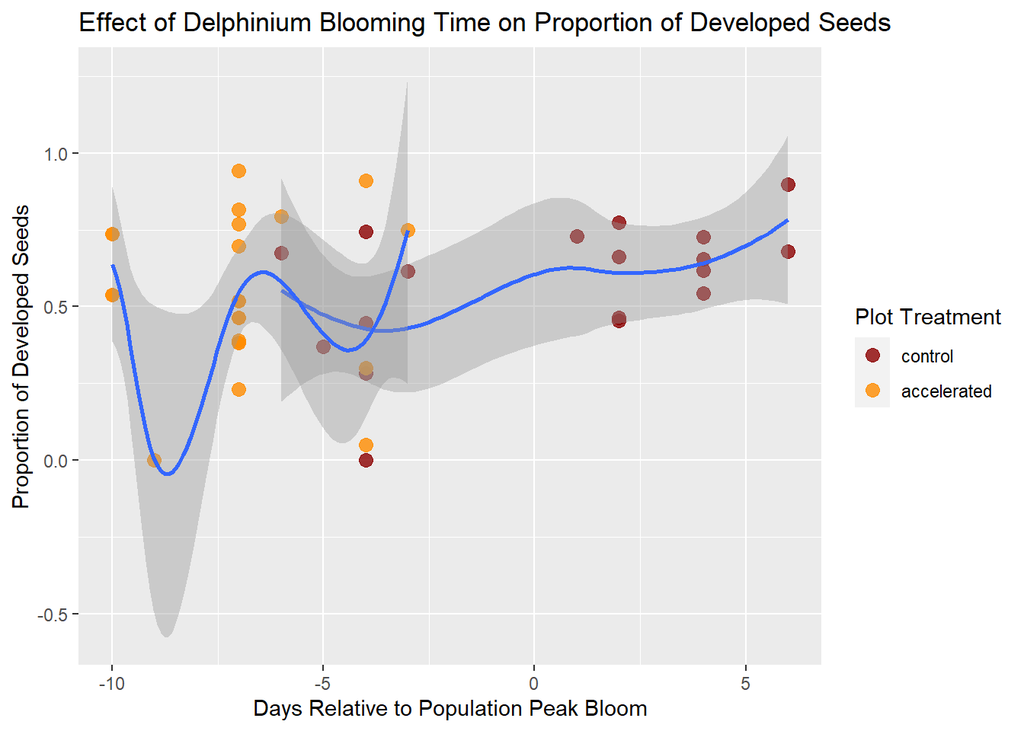

```r
delph.open<-delph.open[!is.na(delph.open$prop.dev.seeds),] #removing NA values in proportion column
ggplot(delph.open, aes(x=delph.open$relative.position, y=delph.open$prop.dev.seeds, group=plot.treat)) +
  labs(title="Effect of Delphinium Blooming Time on Proportion of Developed Seeds", y="Proportion of Developed Seeds",x="Days Relative to Population Peak Bloom") +
  geom_point(aes(color=plot.treat),size=3, alpha = 0.8) +
  scale_color_brewer(palette="Dark2") + labs(color="Plot Treatment") +
  scale_color_manual(labels= c("control","accelerated"), values = c("control"="darkred","manip"="darkorange")) +
  geom_smooth()
```

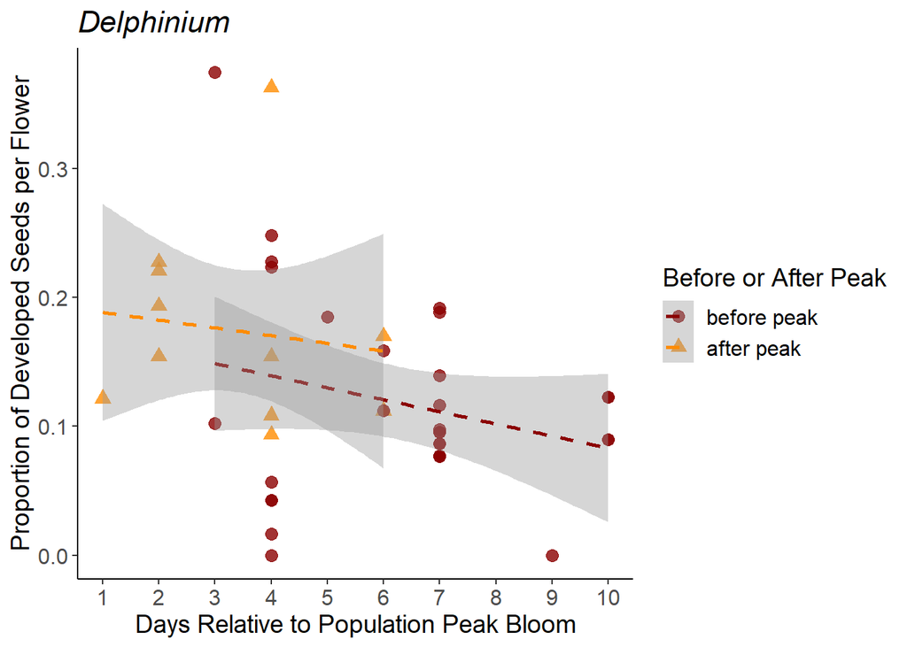

```r
ggplot(delph.open, aes(x=delph.open$deviation, y=(delph.open$prop.dev.seeds/delph.open$X.flowers), group= delph.open$early.late)) +
  labs(y="Proportion of Developed Seeds per Flower",x="Days Relative to Population Peak Bloom",title="Delphinium") +
  theme_classic() + theme(plot.title = element_text(face="italic"))+
  scale_x_continuous(breaks=seq(0,10,1)) +
  geom_point(size=3, alpha = 0.8, aes(color=early.late,shape=early.late)) +
  geom_smooth(method="glm",linetype="dashed",aes(color=early.late)) +
  scale_color_brewer(palette="Dark2") +
  labs(color="Before or After Peak",shape="Before or After Peak") +
  scale_color_manual(labels= c("before peak","after peak"), values = c("early"="darkred","late"="darkorange")) +
  scale_shape_manual(labels= c("before peak","after peak"), values = c("early"="circle","late"="triangle"))+
  theme(axis.text = element_text(size=12),axis.title = element_text(size=14),title = element_text(size=14),legend.text = element_text(size=12))
```

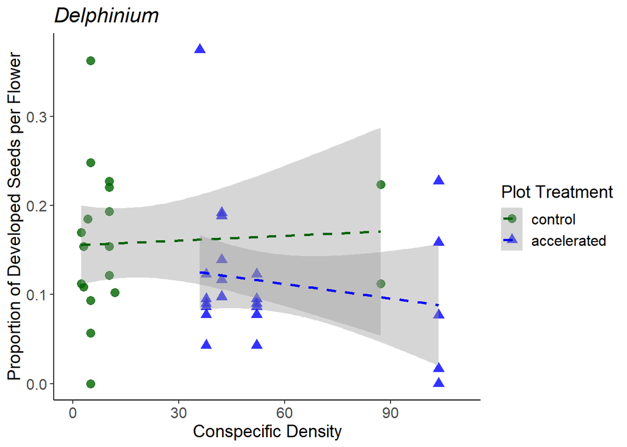

```r
ggplot(delph.open, aes(x=delph.open$number.conspecifics, y=delph.open$prop.dev.seeds/delph.open$X.flowers, group= delph.open$plot.treat)) +
  labs(y="Proportion of Developed Seeds per Flower",x="Conspecific Density",title="Delphinium") +
  theme_classic() + theme(plot.title = element_text(face="italic"))+
  geom_point(size=3, alpha = 0.8, aes(color=plot.treat,shape=plot.treat)) +
  geom_smooth(method="glm",linetype="dashed",aes(color=plot.treat)) +
  scale_color_brewer(palette="Dark2") +
  labs(color="Plot Treatment",shape="Plot Treatment") +
  scale_color_manual(labels= c("control","accelerated"), values = c("control"="darkgreen","manip"="blue")) +
  scale_shape_manual(labels= c("control","accelerated"), values = c("control"="circle","manip"="triangle"))+
  xlim(0,110) +
  theme(axis.text = element_text(size=12),axis.title = element_text(size=14),title = element_text(size=14),legend.text = element_text(size=12))
```

Finally, we added pollinator activity.

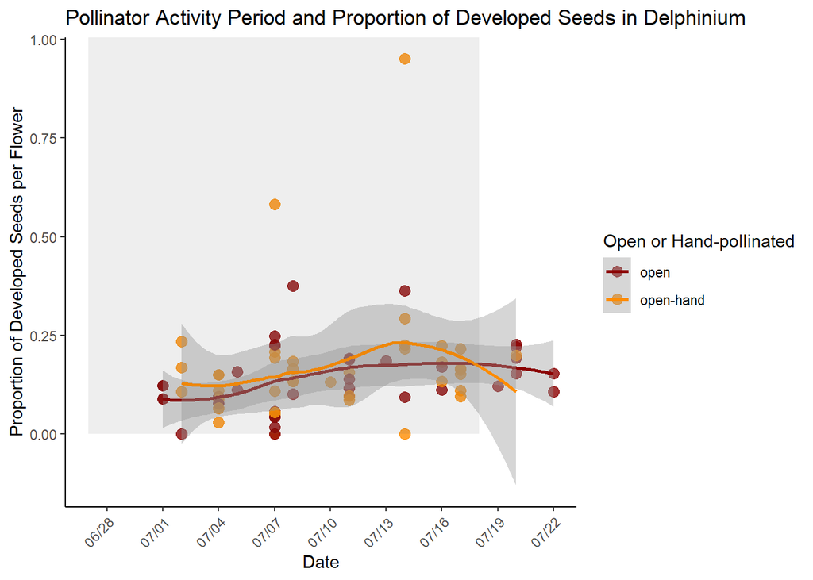

```r
ggplot(delph, aes(x=as.Date.factor(delph$midpoint), y=delph$prop.dev.seeds/delph$X.flowers, group= delph$treat)) +
  labs(y="Proportion of Developed Seeds per Flower",x="Date", title="Pollinator Activity Period and Proportion of Developed Seeds in Delphinium") +
  theme_classic() +
  geom_point(size=3, alpha = 0.8, aes(color=treat)) +
  geom_smooth(aes(color=treat)) +
  scale_color_brewer(palette="Dark2") +
  labs(color="Open or Hand-pollinated") +
  scale_color_manual(labels= c("open","open-hand"), values = c("open"="darkred","open-hand"="darkorange")) +
  theme(axis.text.x = element_text(angle = 45, hjust = 1)) +
  annotate("rect",xmin=as.Date.character("2019-06-27"), xmax=as.Date.character("2019-07-18"),ymin=0,ymax=Inf,alpha=0.1) +
  scale_x_date(date_breaks = "3 days", date_labels = "%m/%d")
```

# 6 Some last figures

## 6.1 Pollen limitation

Some quick bar graphs to compare open and hand-pollinated treatment affected seed set in the three species.

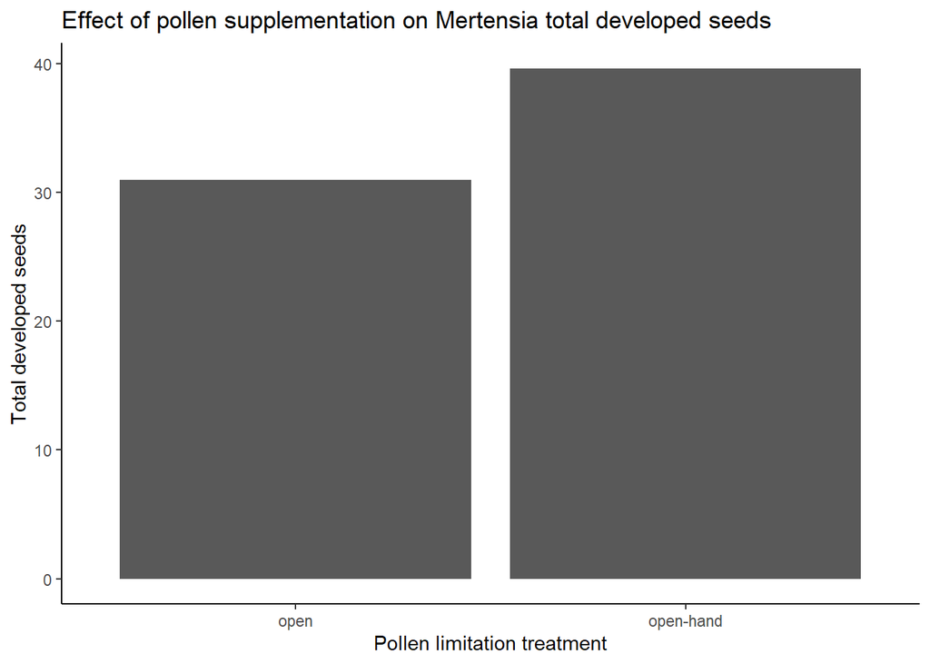

```r
#Mertensia plots with total developed seeds per flower and proportion of developed seeds per flower
ggplot(mert, aes(x=treat, y=dev.seed/flowers)) +
  labs(y="Total developed seeds", x="Pollen limitation treatment", title="Effect of pollen supplementation on Mertensia total developed seeds") +
  theme_classic() +
  geom_col()
```

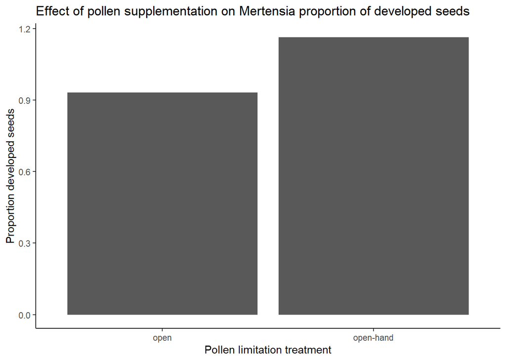

```r
ggplot(mert, aes(x=treat, y=prop.dev.seeds/flowers)) +
  labs(y="Proportion developed seeds", x="Pollen limitation treatment",title="Effect of pollen supplementation on Mertensia proportion of developed seeds") +
  theme_classic() +
  geom_col()
```

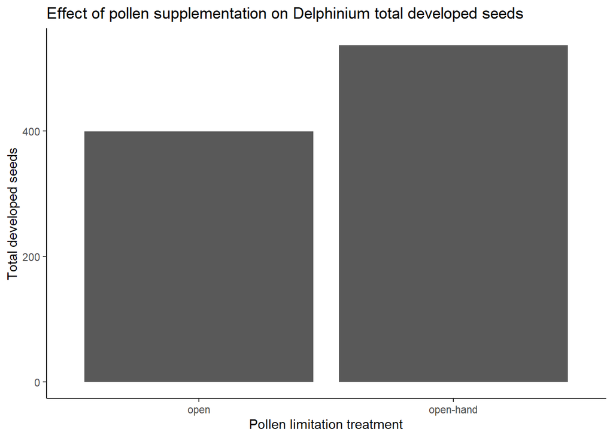

```r
#Delphinium plots with total developed seeds per flower and proportion of developed seeds per flower
ggplot(delph, aes(x=treat, y=total.seeds/X.flowers)) +
  labs(y="Total developed seeds", x="Pollen limitation treatment",title="Effect of pollen supplementation on Delphinium total developed seeds") +
  theme_classic() +
  geom_col()
```

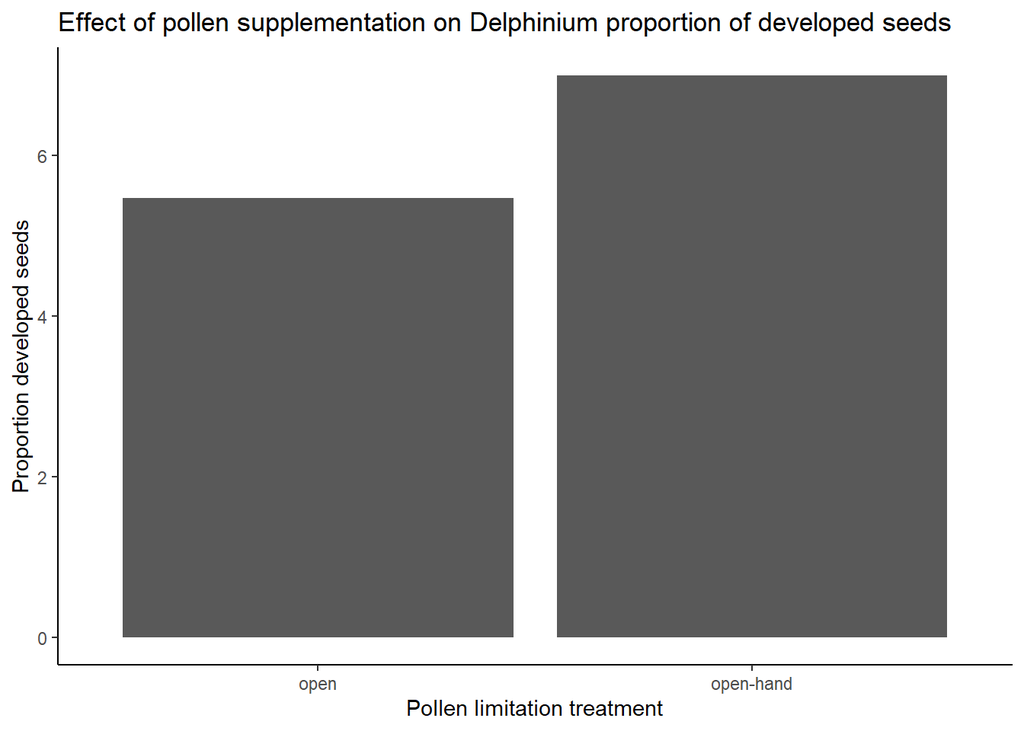

```r
ggplot(delph, aes(x=treat, y=prop.dev.seeds/X.flowers)) +
  labs(y="Proportion developed seeds", x="Pollen limitation treatment",title="Effect of pollen supplementation on Delphinium proportion of developed seeds") +
  theme_classic() +
  geom_col()
```

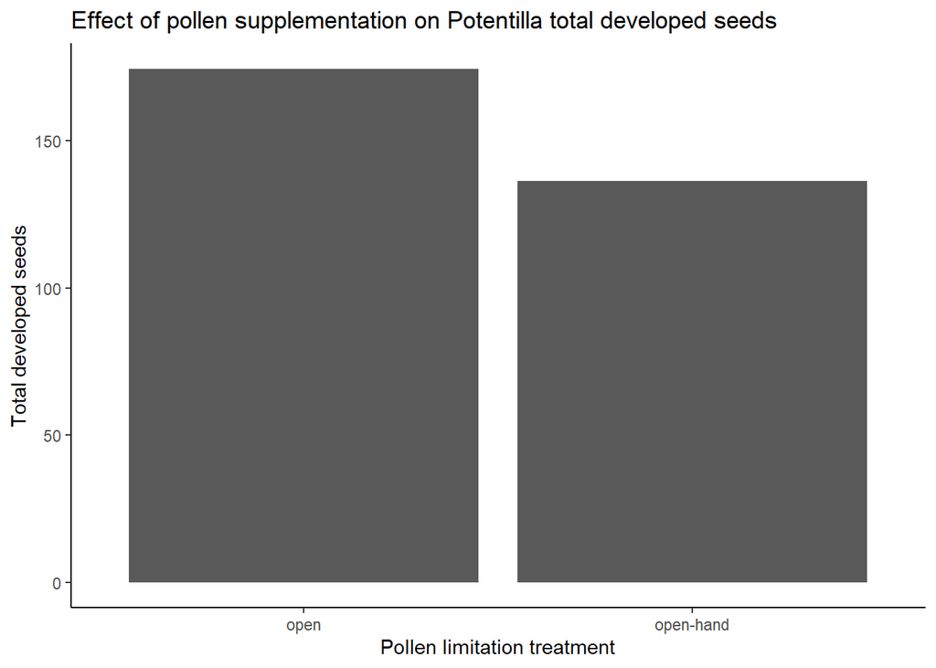

```r
#Potentilla plots with total developed seeds per flower
ggplot(pot, aes(x=treat, y=total.seeds/X.flowers)) +
  labs(y="Total developed seeds", x="Pollen limitation treatment",title="Effect of pollen supplementation on Potentilla total developed seeds") +
  theme_classic() +
  geom_col()
```

## 6.2 Flower number figures

We created a few last figures to see the relationship between plot treatment and flower number (on the individuals, not conspecific density flower counts).

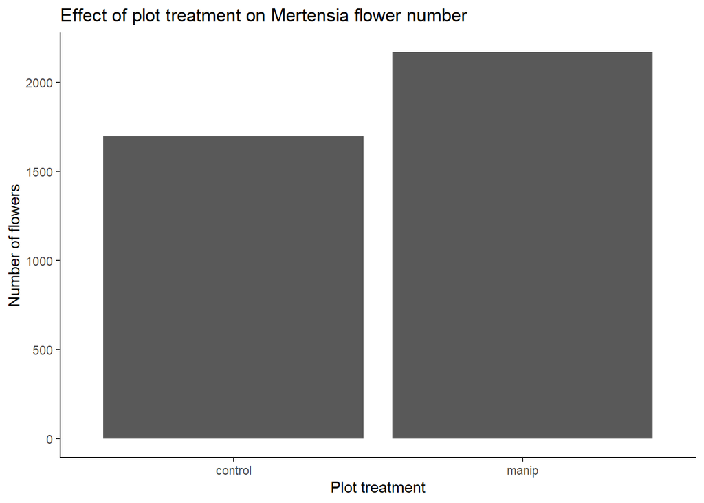

```r
#number of Mertensia flowers in each plot treatment
ggplot(mert, aes(x=plot.treat, y=flowers)) +
  labs(y="Number of flowers", x="Plot treatment",title="Effect of plot treatment on Mertensia flower number") +
  theme_classic() +
  geom_col()
```

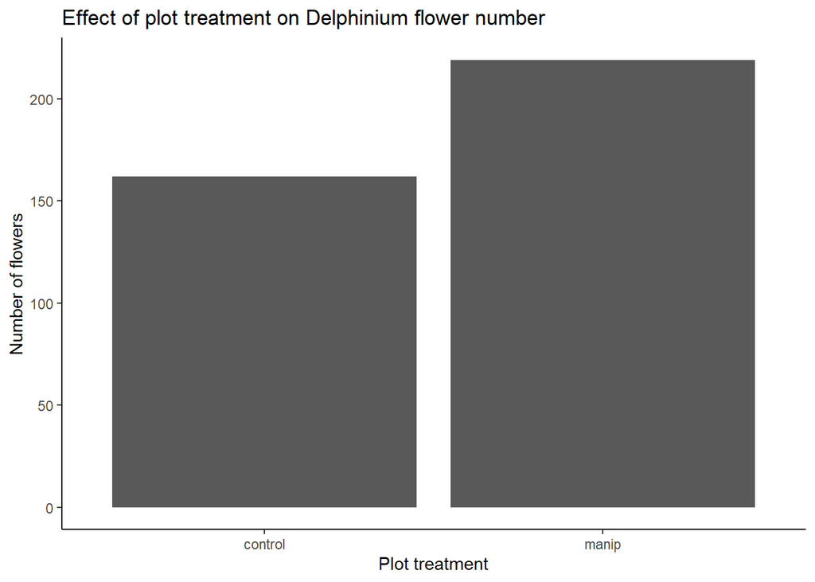

```r
#number of Delphinium flowers in each plot treatment
ggplot(delph,aes(x=plot.treat, y=X.flowers)) +
  labs(y="Number of flowers", x="Plot treatment",title="Effect of plot treatment on Delphinium flower number") +
  theme_classic() +
  geom_col()
```

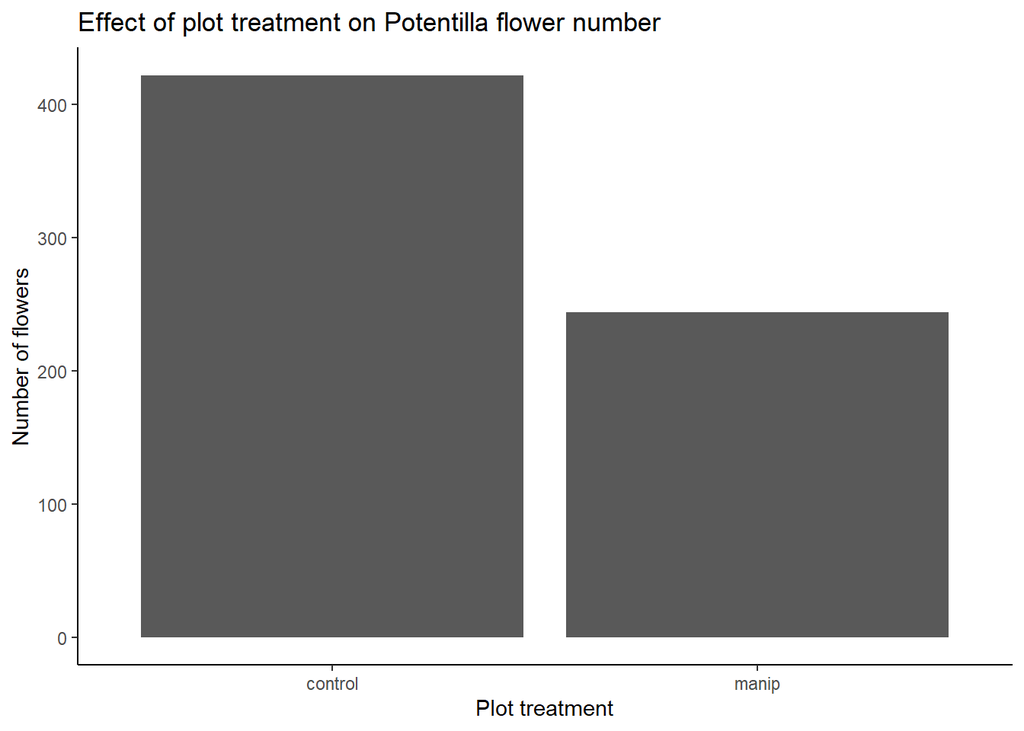

```r
#number of Potentilla flowers in each plot treatment
ggplot(pot,aes(x=plot.treat, y=X.flowers)) +
  labs(y="Number of flowers", x="Plot treatment",title="Effect of plot treatment on Potentilla flower number") +
  theme_classic() +
  geom_col()
```